# 第4回 利子と価格①：金利計算

経済データ入門

第4回

利子と価格①：金利計算

複利の増え方は、利率と時間の両方で決まる

経済データ入門

第4回 — Topic01

利率と利息

その「金利」は、いつの、誰のいくらか

## この回の道のり

1

利率と利息

演習 4-1

預金金利のカード

2

単利と複利

演習 4-2

20 年に伸ばす

3

絶対参照

演習 4-3

元金を 2 倍に

4

利率と時間

演習 4-4

カードローンで 5 年

いまここ — その「金利」は、いつの、誰のいくらか

## 前回の振り返り

前回のポイント — 第3回「賃金・貯蓄と統計の基本」

Q: 平均の数字を見たとき、何を確かめたか

- **平均と中央値**：平均は 1 人の大きな値に引っ張られる
- **散らばり**：平均が同じでも、散らばりがちがえば別のデータ
- **データカード**：数字の身元を 7 項目で書いた

今日はお金の値段、金利。いつの、誰の値かまで確かめる

## 「複利」シートで作る所

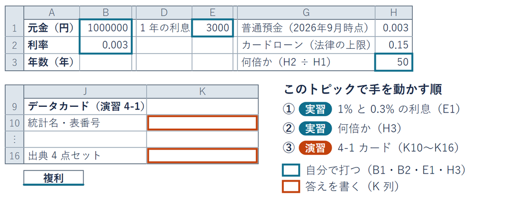

置き場は演習ブック lec4-exercise.xlsx の「複利」  
シート。1 枚で回を通す

## たしかめ：いまの普通預金の金利

銀行口座にお金を置くのは、**銀行にお金を貸している**こと  
だから預金にも金利が付く。いま（2026年9月時点）は何%か

A

**約 3%**

B

**約 0.3%**

C

**約 0.03%**

D

**約 0.003%**

1 つ決めてから先へ。答えは、このあと配布 PDF で確かめる

## 100 万円を 1% で 1 年預けたときの利息

[figure not shown]

- **サンプルデータ**：説明用の数（100 万円・1%）。  
  置き場は lec4-exercise.xlsx の B1・B2

1% は 100 個のうち 1 個。1 年後は 101 万円

## 元金・利率・利息

用語

**元金**＝預けた・借りた、もとのお金

**利率**（金利）＝元金に 1 年で付く利息の割合

**利息**＝実際に付いたお金

式

利息 ＝ 元金 × 利率

- **今回は**：1,000,000 × 0.01 ＝ 10,000（円）
- **% を小数に**：1% ＝ 1 ÷ 100 ＝ 0.01
- **預金では**：あなたが銀行に貸す側。利息を受け取る

## 失敗例 1% を 10 万円と読む誤り

1% を 0.1 にした  
1,000,000 × 0.1 ＝ 100,000  
これは 10% のときの利息

1% は 0.01  
1,000,000 × 0.01 ＝ 10,000  
100 個のうち 1 個

- **なぜ起きるか**：「1 割」と「1%」を混ぜやすい。1 割は 10%
- **確かめ方**：100 万円の 1% は、100 万円 ÷ 100 ＝ 1 万円

## 1 年の利息の式

1. **打つ**：B1 に 1000000  
   B2 に 0.01（カンマは打たない）
2. **式**：E1 に `=B1*B2`  
   `*` は掛け算の記号

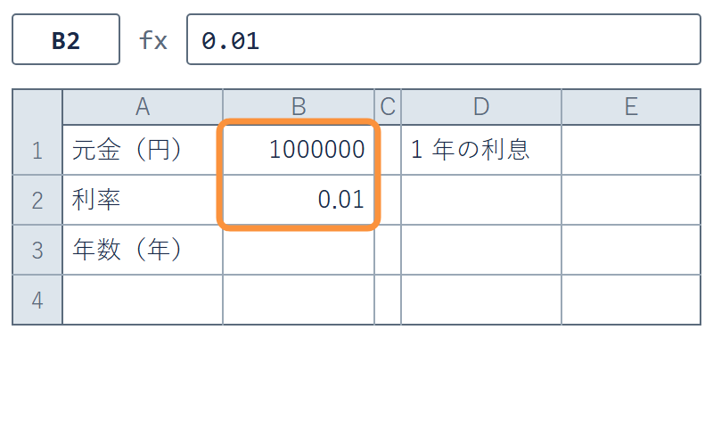

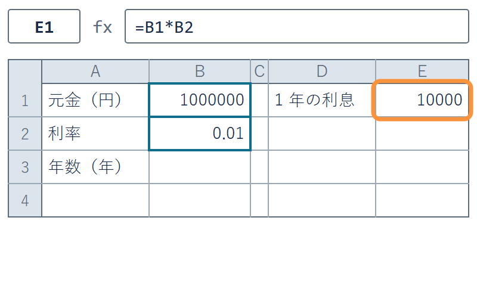

1% は 0.01 なので、E1 は 1 万円の 10000

✋ 動画を止めて STEP 1・2 を進め、E1 が 10000 なら再生に戻る

## 配布 PDF のいまの普通預金

出典：日本銀行「預金種類別店頭表示金利の平均年利率等（月次）」  
配布 PDF（1 ページ）の表の、いちばん下の行

| 時点 | 普通預金の金利 |
| --- | --- |
| 2026年9月 | **0.322%**（計算は 0.3% で） |

- **四択の答え**：B の約 0.3%
- **店頭表示金利の平均**：毎月 15 日時点の、銀行の店頭の金利
- **税引き前**：受け取るときは税金が引かれる
- **配布 PDF**：lecture04_預金金利_日本銀行_2026年9月時点.pdf

## いまの金利での 1 年の利息

1. **見る**：配布 PDF の 2026年9月の行  
   普通預金 0.322（計算は 0.3% で）
2. **書き換える**：B2 を 0.003 に  
   E1 の式はそのまま

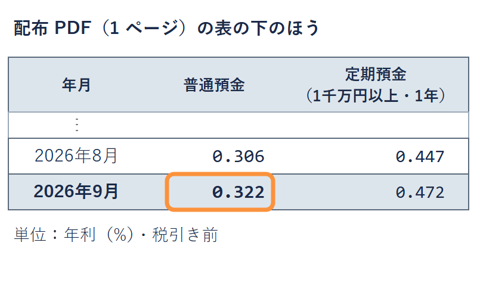

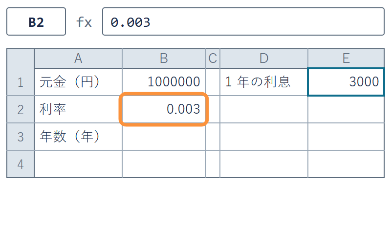

E1 の式は 1 文字も直さずに 1,000,000 × 0.003 ＝ 3,000

✋ 動画を止めて STEP 1・2 を進め、E1 が 3000 なら再生に戻る

## 借りる側の金利

出典：利息制限法 第1条（元本 100 万円以上の上限は年 15%）  
法律で決まった上限なので、毎年は変わらない

| 100 万円を 1 年 | 金利 | 利息 |
| --- | --- | --- |
| 預ける（普通預金・2026年9月時点） | 0.3% | 3,000 円 |
| 借りる（カードローンの上限） | 15% | 150,000 円 |

- **計算**：1,000,000 × 0.15 ＝ 150,000
- **置き場**：0.003 は H1、0.15 は H2 に印刷してある

借りる側は、預ける側の何倍か。5 倍・50 倍・500 倍から 1 つ決める

## 普通預金とカードローンの倍率

1. **見る**：H1 の 0.003 と  
   H2 の 0.15（印刷済み）
2. **割る**：H3 に `=H2/H1`

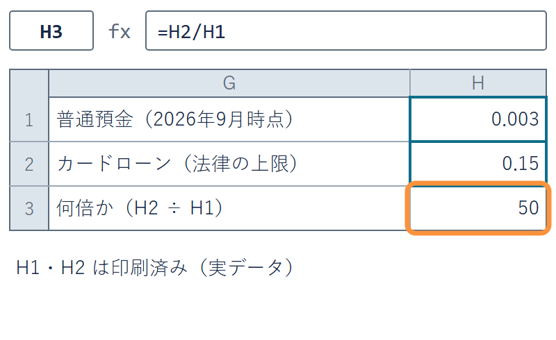

借りる側の金利は 15 ÷ 0.3 ＝ 50 倍

✋ 動画を止めて STEP 1・2 を進め、H3 が 50 なら再生に戻る

## 毎年ちがう普通預金の金利

決め

金利の数には、**いつの値か**（時点）を添える

| 時点 | 普通預金の金利 |
| --- | --- |
| 2023年9月 | 0.001% |
| 2024年9月 | 0.091% |
| 2025年9月 | 0.183% |
| **2026年9月** | **0.322%** |

出典は配布 PDF の灰色の行。来年 9 月はまた別の数

## 政策金利と市中金利

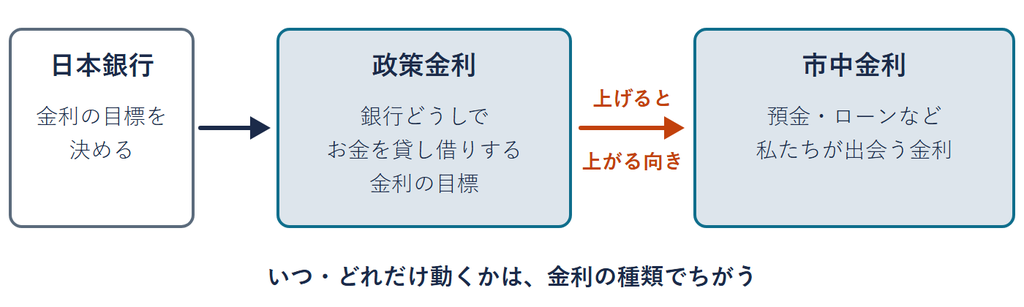

- **普通預金は市中金利の 1 つ**：日本銀行が政策金利を  
  上げると、上がる向きに動く
- **数は年でちがう**：だから金利を書くときは、時点を添える

## 失敗例 種類と時点を書かない金利

何の金利かを書かない  
「いまの金利は 0.3%」  
どの金利か、  
いつの値か分からない

種類と時点を添える  
「普通預金は 0.322%  
（日本銀行・2026年9月時点）」

- **なぜ起きるか**：「金利」は 1 つの数だと思いやすい
- **自分の口座とはちがう**：店頭表示の平均で、銀行ごとに金利はちがう
- **どう防ぐか**：種類・出どころ・時点の 3 つを添える

## 演習 4-1 預金金利のデータカード

演習 4-1

日本銀行の預金金利のデータカード 7 項目を埋める

1. **見るもの**：配布 PDF（1 ページ）の上の欄と表
2. **書く場所**：K10〜K16 の 7 項目（J 列に項目名がある）
3. **時点と取得日**：2026年9月の値と、PDF にある取得日 2026年9月22日
4. **落とし穴**：「自分の口座とはちがう」と、自分で気づいたことを 1 つ

✋ 動画を止めて 6 分。K10〜K16 が埋まったら再生に戻る

## 演習 4-1 の答えの例

| 項目 | 日本銀行の預金金利の例 |
| --- | --- |
| 統計名・表番号 | 預金種類別店頭表示金利の平均年利率等 （月次）— 統計表 ir02_m_1 |
| 作成機関 | 日本銀行 |
| 調査の種類 | 銀行が店頭に表示した金利の記録（業務統計）・毎月 |
| 単位・基準 | 年利（%）・**税引き前**・毎月 15 日時点の平均 |
| 定義の落とし穴 | **店頭表示の平均で、自分の口座の金利ではない** ほかに**自分で気づいたこと**を 1 つ |
| 入手先・取得日 | 日本銀行のサイト（配布 PDF）・**2026年9月22日** |
| 出典 4 点セット | 日本銀行「預金種類別店頭表示金利の平均年利率等（月次）」 統計表 ir02_m_1・普通預金、2026年9月22日取得 |

欄は第3回までと同じ 7 つ。K10〜K16 にこの形で書けていればよい

## まとめ

- **利息は元金 × 利率**：100 万円 × 1% ＝ 1 万円。1% は 0.01
- **いまの普通預金**：0.322%（2026年9月時点・日本銀行の店頭表示の平均）
- **借りる側**：上限 15%（利息制限法）は普通預金の 50 倍
- **金利は毎年ちがう**：種類・出どころ・時点を添えて書く

次は、この利息が 2 年目、3 年目にどう積み重なるかを見る

経済データ入門

第4回 — Topic02

単利・複利と前提セル

足す世界と、掛ける世界

## この回の道のり

1

利率と利息

演習 4-1

預金金利のカード

2

単利と複利

演習 4-2

20 年に伸ばす

3

絶対参照

演習 4-3

元金を 2 倍に

4

利率と時間

演習 4-4

カードローンで 5 年

いまここ — 足す世界と、掛ける世界

## 「複利」シートで作る所

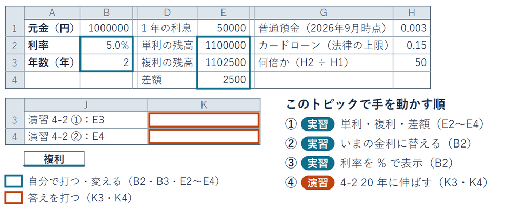

前と同じ「複利」シート。年数の B3 と、  
E2〜E4 の 3 つの式を足す

## たしかめ：2 年後に多い銀行

100 万円を年利 5% で 2 年預ける  
**A 銀行**（徒歩 5 分）は、毎年元金にだけ利息が付く  
**B 銀行**（徒歩 20 分）は、付いた利息にも次の年から利息が付く

ア

**A 銀行が多い**

イ

**B 銀行が多い**

ウ

**どちらも同じ**

1 つ決めてから先へ。年利 5% はサンプルデータ（説明用の数）

## A 銀行と B 銀行の 3 年

[figure not shown]

- **サンプルデータ**：説明用の数（100 万円・年利 5%）。  
  置き場は lec4-exercise.xlsx の B1・B2

答えはイ。差は 2 年目の 2,500 円から開いていく

## 2 年目の 2,500 円の出どころ

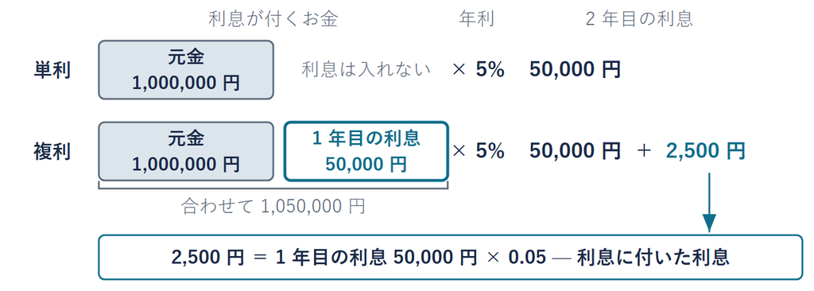

単利は 100 万円に 5%、複利は 105 万円に 5%

## 単利と複利

用語

**単利**＝利息が毎年、元金にだけ付く（A 銀行）

**複利**＝付いた利息も元金に入れる（B 銀行）

- **単利は足す世界**：毎年、同じ 50,000 円を足す
- **複利は掛ける世界**：毎年、残高を 1.05 倍にする
- **利息にも利息**：2 年目からは、付いた利息にも利息が付く
- **1.05 の出どころ**：1 ＋ 0.05 で、残高に 5% ぶんを足した倍率

## くり返し掛ける記号 `^`

記号

**`^`**（べき乗）＝同じ数をくり返し掛ける  
1.05 × 1.05 は 1.05^2 と書き、「1.05 の 2 乗」と読む

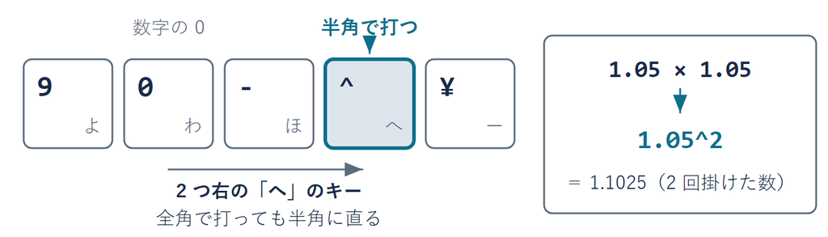

## 単利と複利の 2 本の式

式

**単利**：残高 ＝ 元金 ×（1 ＋ 利率 × 年数）

**複利**：残高 ＝ 元金 ×（1 ＋ 利率）^ 年数

- **今回の単利**：1,000,000 ×（1 ＋ 0.05 × 2）＝ 1,100,000
- **今回の複利**：1,000,000 ×（1 ＋ 0.05）^ 2 ＝ 1,102,500
- **年数を変えても**：式の形は同じ。年数の所だけが変わる

## 数を書き込んだ式とセルを指す式

20 年後の複利の残高を、セル 1 つで出したい。  
あとで 10 年に変えたくなったら

✗ 数を式に書き込む  
`=1000000*1.05^20`  
10 年にするには、  
式の中の 20 を探して打ち直す  
どの数が元金か、  
式を読まないと分からない

◯ 数はセルに置き、  
式はセルを指す  
`=B1*(1+B2)^B3`  
10 年にするには、  
B3 を 10 に書き換えるだけ  
元金・利率・年数が、  
見出しの隣に見えている

## 前提セル

用語

**前提セル**＝元金・利率・年数のように、  
計算の前提になる数を置くセル  
式には数を書かず、前提セルの番地を指す

- **このシートの前提セル**：B1 元金・B2 利率・B3 年数
- **効き目**：前提セルを書き換えると、指している式の答えがすべて変わる
- **読める**：A 列の見出しの隣にあるので、何の数か分かる

## 2 年後の単利の式

1. **打つ**：B2 を 0.05 に  
   B3 に 2（B1 はそのまま）
2. **式**：E2 に `=B1*(1+B2*B3)`  
   単利の式を番地で書く

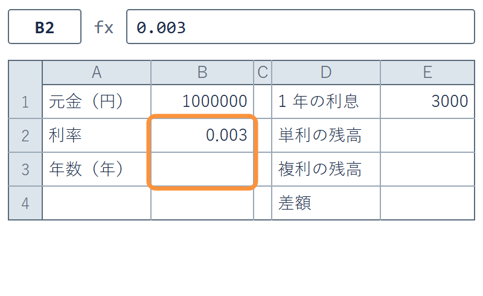

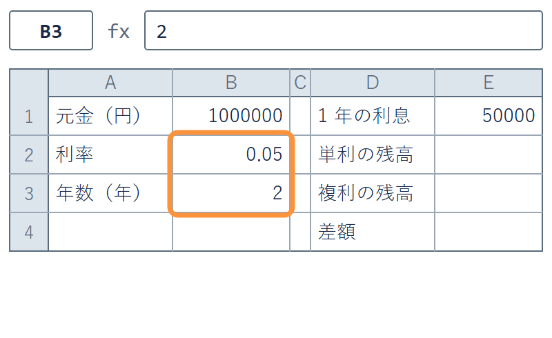

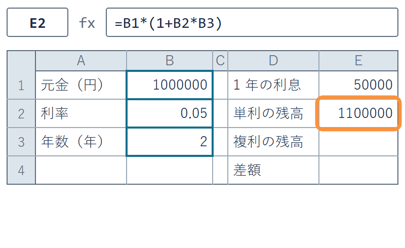

E2 は 1100000 で、A 銀行の 2 年後と同じ

✋ 動画を止めて STEP 1・2 を進め、E2 が 1100000 なら再生に戻る

## 2 年後の複利と差額の式

1. **式**：E3 に `=B1*(1+B2)^B3`  
   複利の式を番地で書く
2. **差**：E4 に `=E3-E2`  
   複利から単利を引く

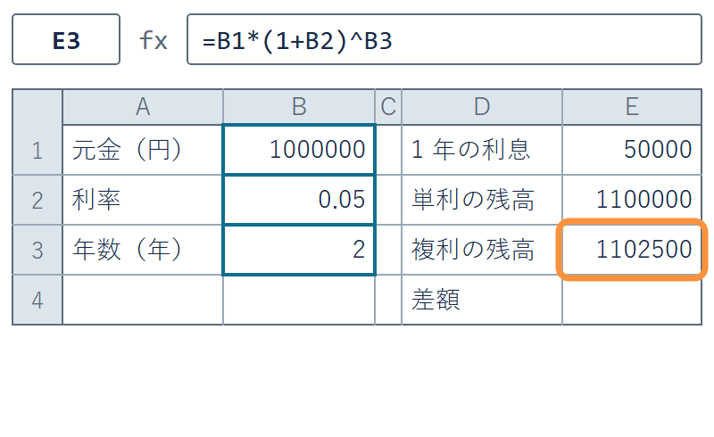

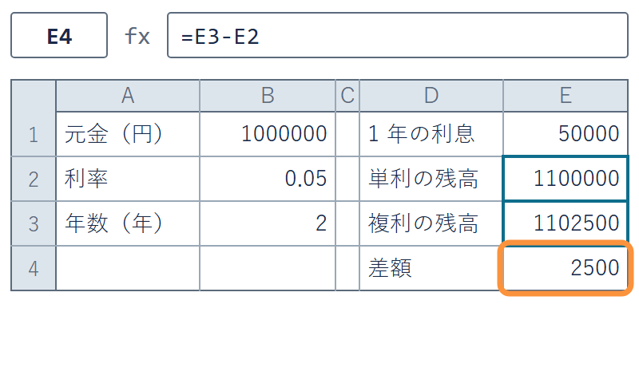

E3 は 1102500 で、E4 は 2500 になる。2 年目の 2,500 円が式で出る

✋ 動画を止めて STEP 1・2 を進め、E4 が 2500 なら再生に戻る

## いまの普通預金での 2 年

出典：日本銀行（配布 PDF）  
の普通預金 2026年9月時点 0.322%。計算は 0.3%  
置き場は lec4-exercise.xlsx の H1（0.003）

| 100 万円を 2 年 | 年利 5%（サンプル） | 年利 0.3%（いまの普通預金） |
| --- | --- | --- |
| 単利の残高 | 1,100,000 | 1,006,000 |
| 複利の残高 | 1,102,500 | 1,006,009 |
| 差額 | 2,500 | **9** |

- **5% の差**：50,000 × 0.05 ＝ 2,500（1 年目の利息に付いた利息）
- **0.3% の差**：3,000 × 0.003 ＝ 9（同じ部品で、桁が小さい）
- **差が小さい理由**：この回の最後で確かめる

## いまの金利への書き換え

1. **書き換える**：B2 を 0.003 に  
   （H1 と同じ値・式はそのまま）
2. **戻す**：E4 が 9 になったのを見たら  
   B2 を 0.05 に戻す

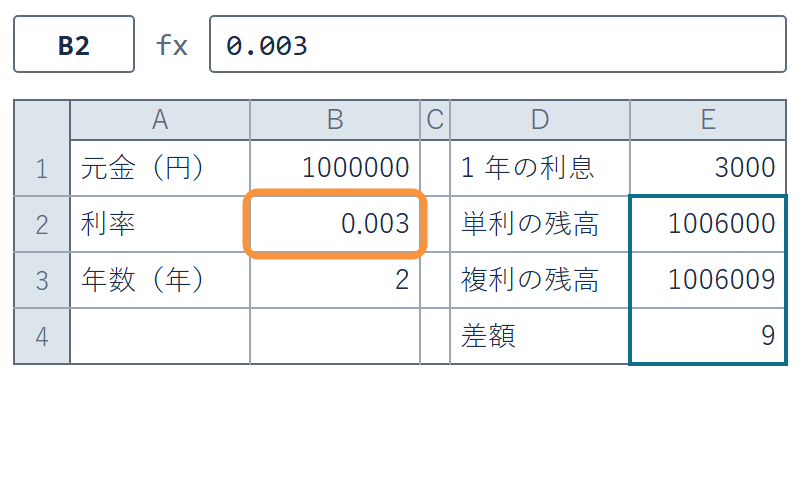

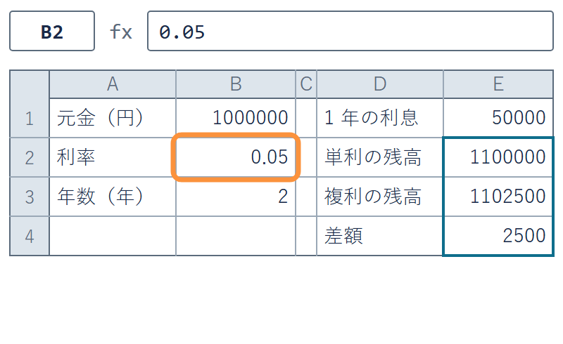

式は 1 文字も直していない。前提セルを替えただけで 3 つの答えが変わる

✋ 動画を止めて STEP 1・2 を進め、E4 が 9 になり B2 を 0.05 に戻したら再生に戻る

## 利率のパーセント表示

1. **開く**：B2 を選んで `Ctrl + 1`  
   （Mac は `⌘ + 1`）
2. **選ぶ**：分類「パーセンテージ」  
   小数点以下の桁数 1 → OK

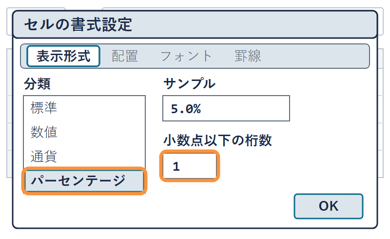

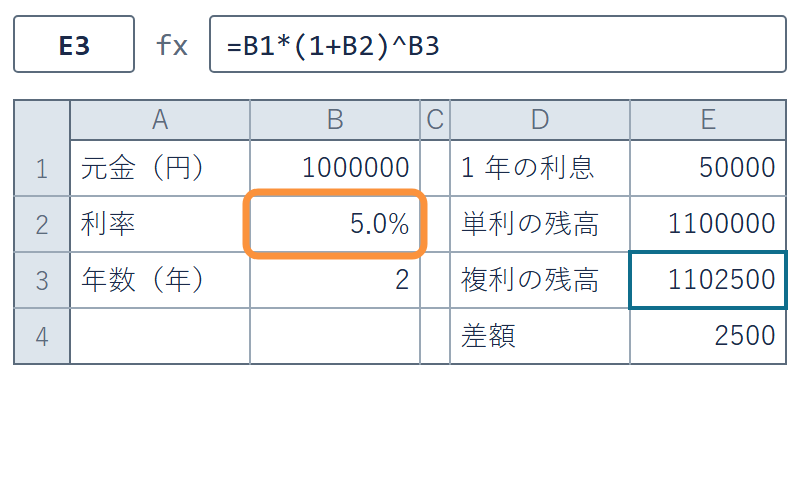

B2 の見え方は 5.0% に変わる。中身は 0.05 のままで、E3 も変わらない

✋ 動画を止めて STEP 1・2 を進め、B2 が 5.0% なら再生に戻る

## 失敗例 利率に 5 と打った前提セル

表示が標準の B2 に 5 と打つ  
年利 500% の意味になる  
B3 が 1 のとき、E3 は 6,000,000

B2 に 0.05 と打つ  
年利 5%  
B3 が 1 のとき、E3 は 1,050,000

- **なぜ起きるか**：「5%」の 5 だけを打ちたくなる
- **確かめ方**：1 年後の残高が元金の 1.05 倍か、大きさで見る
- **打ち方**：0.05 と打つか、% を付けて 5% と打つ。中身はどちらも 0.05

## 失敗例 `*` と `^` の取り違え

`*` で書く  
`=(1+B2)*B3` は 1.05 × 20  
B3 が 20 のとき 21

`^` で書く  
`=(1+B2)^B3` は 1.05 を 20 回掛ける  
B3 が 20 のとき約 2.65

- **なぜ起きるか**：「20 年ぶん」を「20 倍」と読みやすい
- **`*` は 1 回、`^` はくり返し**：複利の年数は `^` の右に置く

## たしかめ：20 年後の利息

1 年目の利息は 5 万円。20 年なら 5 万円 × 20 年 ＝ 100 万円？  
B 銀行（複利）に 100 万円を 20 年預けたときの利息は

ア

**ちょうど 100 万円**

イ

**100 万円より少ない**

ウ

**100 万円より多い**

1 つ決めてから先へ。答えは次の演習で、自分のシートで出す

## 演習 4-2 20 年に伸ばした残高

演習 4-2

B3 を 20 にすると、E3 と E4 はいくつになるか

1. **変える所**：B3 を 2 から 20 に（式は直さない）
2. **書く場所**：E3 の値を K3 に、E4 の値を K4 に打つ（円未満は四捨五入）
3. **戻さない**：B3 は 20 のまま、次のトピックで使う
4. **考える**：E3 から元金を引いた利息を、予想の 100 万円と比べる

✋ 動画を止めて 3 分。K3・K4 に数を打ったら再生に戻る

## 演習 4-2 の答え

| B3 が 20 のとき | 値 | 打つ所 |
| --- | --- | --- |
| E3 複利の残高 | 2,653,298 | K3 |
| E4 差額（複利 − 単利） | 653,298 | K4 |
| 複利の利息（E3 − 元金） | 1,653,298 | — |

- **予想の答えはウ**：利息は約 165 万円で、100 万円より多い
- **5 万円 × 20 年は単利**：E2 は 2,000,000（利息 100 万円）
- **前提セルの効き目**：B3 を書き換えただけで、20 年後が出た

差は 2 年で 2,500 円、20 年で 653,298 円。どう開いていくかは次で表にする

## まとめ

- **単利は足す世界**：毎年、元金に付く同じ利息を足す
- **複利は掛ける世界**：毎年 1 ＋ 利率 を掛ける。くり返しは `^`
- **2 年目の差**：1 年目の利息に付いた利息  
  （5% で 2,500 円、2026年9月時点の 0.3% で 9 円）
- **前提セル**：数は B1〜B3 に置き、式は番地で指す

次は、0 年から 20 年までを 1 年ずつの表にする

経済データ入門

第4回 — Topic03

絶対参照と複利表

わざと壊してから、`$` で直す

## この回の道のり

1

利率と利息

演習 4-1

預金金利のカード

2

単利と複利

演習 4-2

20 年に伸ばす

3

絶対参照

演習 4-3

元金を 2 倍に

4

利率と時間

演習 4-4

カードローンで 5 年

いまここ — わざと壊してから、`$` で直す

## 「複利」シートで作る所

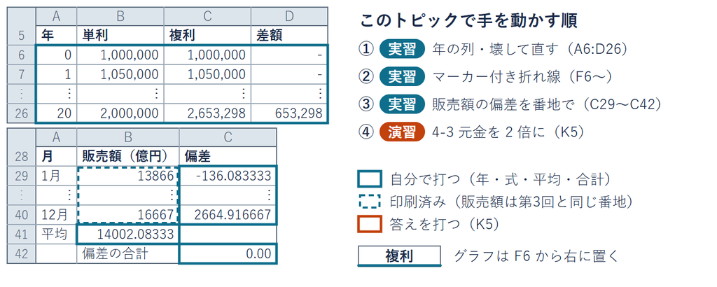

前と同じ「複利」シート。5 行目から 20 年の表、  
29 行目から販売額の偏差

## 20 年の複利表の作り方

**サンプルデータ**：B1 の 100 万円と B2 の年利 5%  
（前のトピックのまま・lec4-exercise.xlsx）

1. **年を並べる**：A6 と A7 に 0 と 1 を打ち、A26 までフィル
2. **わざと壊す**：C6 に複利の式を入れ、C11 までコピー
3. **読む**：コピーした先の式を、数式バーで確かめる
4. **留める**：前提セルの番地が、コピーしても動かないようにする
5. **広げる**：C26 まで。単利の B 列と差額の D 列も
6. **描く**：マーカー付き折れ線

STEP 7 は販売額の偏差。2 と 3 は、わざと通る回り道

## STEP 1 年の列

1. **打つ**：A6 と A7 に 0 と 1  
   （5 行目の見出しは印刷済み）
2. **フィル**：A6:A7 を選び、右下の  
   四角を A26 までドラッグ

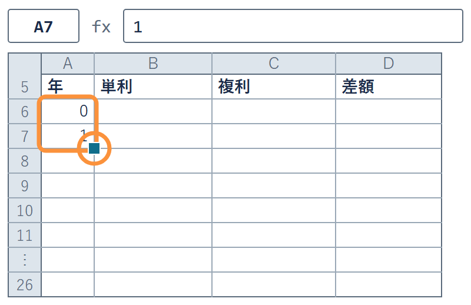

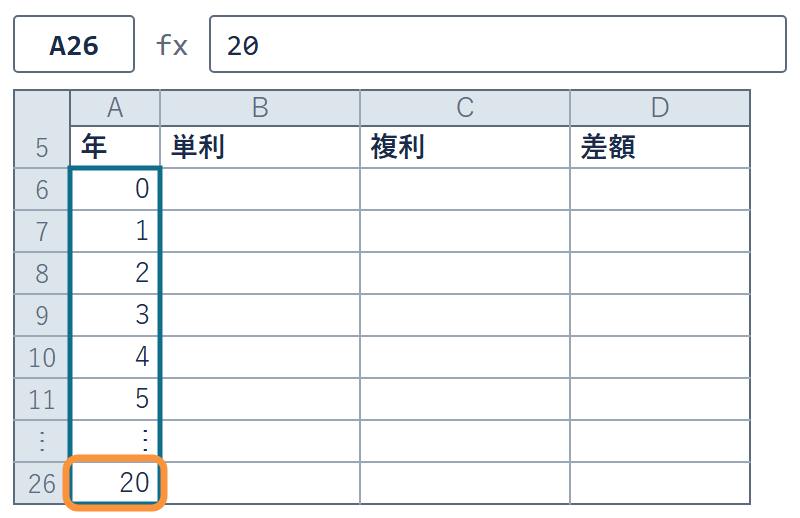

A26 が 20 なら、0 年から 20 年までの 21 行がそろった

✋ 動画を止めて手順 1・2 を進め、A26 が 20 なら再生に戻る

## たしかめ：コピーした先の 1 年目

C6 に `=B1*(1+B2)^A6` と打つと、0 年目なので 1000000 と出る  
この式を C11 までコピーすると、C7（1 年目）は

ア

**1,050,000**

イ

**1,000,000**

ウ

**どちらでもない**

1 つ決めてから先へ。答えは次のページで、自分のシートで出す

## STEP 2 わざと壊すコピー

1. **式**：C6 に `=B1*(1+B2)^A6`  
   （B1 元金・B2 利率・A6 年）
2. **コピー**：C6 の右下の四角を  
   C11 までドラッグ

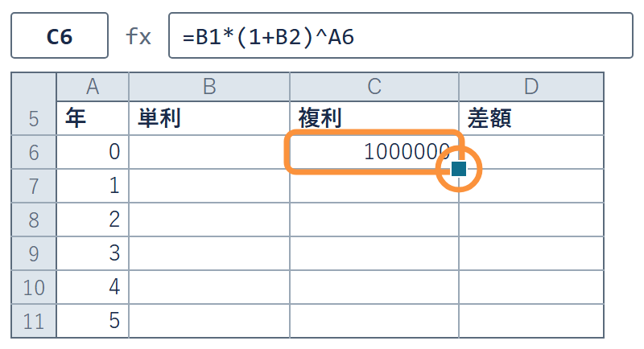

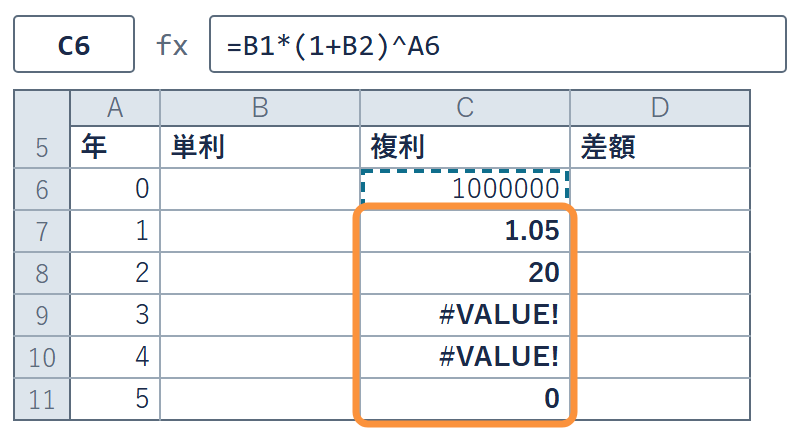

答えはウ。C7 は 1.05 で C8 は 20 になり、その下は #VALUE! と 0

✋ 動画を止めて手順 1・2 を進め、C7 が 1.05 になったら再生に戻る

## STEP 3 数式バーで読む C7

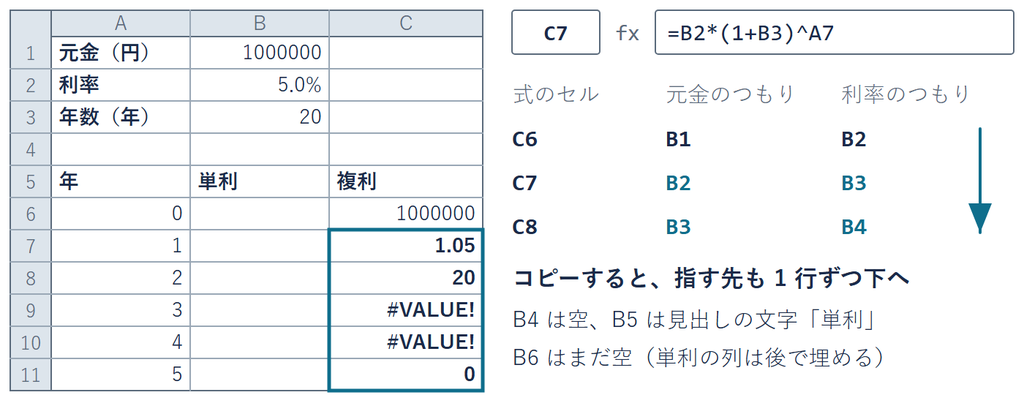

C7 の数式バーは `=B2*(1+B3)^A7`。  
元金のつもりの B1 が、B2 になっている

## C7〜C11 の式の中身

| セル | 数式バー | 中身 | 表示 |
| --- | --- | --- | --- |
| C7 | `=B2*(1+B3)^A7` | 0.05 ×（1 ＋ 20）^ 1 | **1.05** |
| C8 | `=B3*(1+B4)^A8` | 20 ×（1 ＋ 0）^ 2 | **20** |
| C9 | `=B4*(1+B5)^A9` | B5 は見出しの文字「単利」 | **#VALUE!** |
| C11 | `=B6*(1+B7)^A11` | 0 ×（1 ＋ 0）^ 5 | **0** |

- **空のセル**：B4・B6・B7 は空。計算では 0 として扱われる
- **#VALUE!**：文字（見出しの「単利」）を計算に使った印

## コピーで動く番地

- **打ち間違いではない**：C6 の式は正しく、C6 は 1000000
- **番地が動く**：1 行下へコピーすると、式の中の番地も 1 行下へ動く
- **動くのは便利な性質**：第3回で偏差の式を右へ引き、  
  5 人ぶんに広げられたのも番地が動くから
- **困るのは**：前提セルのように、どの行からも同じセルを指したいとき

年の A6 は動いてほしい。元金の B1 と利率の B2 は動いてほしくない

## 絶対参照 `$`

用語

**絶対参照**＝`$` を付けて番地を留める書き方（読みはドル）

`$B$1`＝`$B`（列 B を留める）＋`$1`（行 1 を留める）

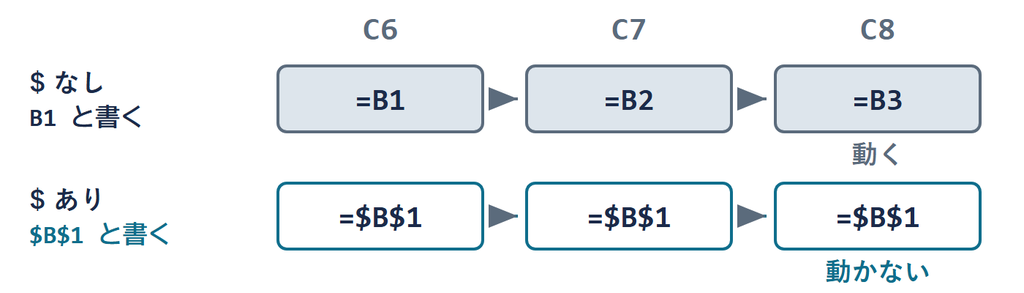

## STEP 4 `F4` で付ける `$`

1. **B1 に**：C6 を選び、数式バーの  
   B1 をクリックして `F4`  
   （Mac は `⌘ + T`）
2. **B2 に**：B2 も同じく `F4`  
   `=$B$1*(1+$B$2)^A6` で Enter  
   A6 には付けない

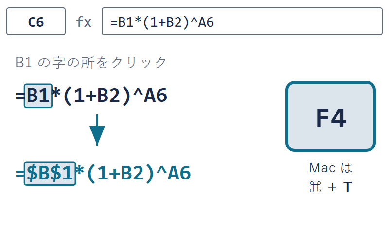

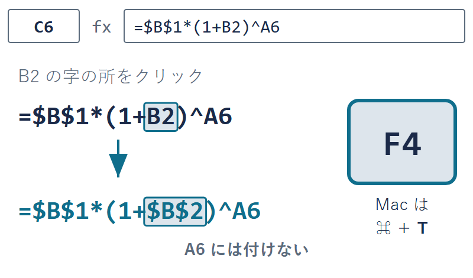

C6 は 1000000 のまま。変わったのは、コピーしたときの指し方

✋ 動画を止めて手順 1・2 を進め、  
C6 の数式バーが `=$B$1*(1+$B$2)^A6` なら再生に戻る

## STEP 5 C26 までのフィル

1. **フィル**：C6 の右下の四角を  
   C26 までドラッグ（壊れた  
   C7〜C11 は上書きされる）
2. **確かめる**：C7 は 1050000  
   C26 は 2653297.705

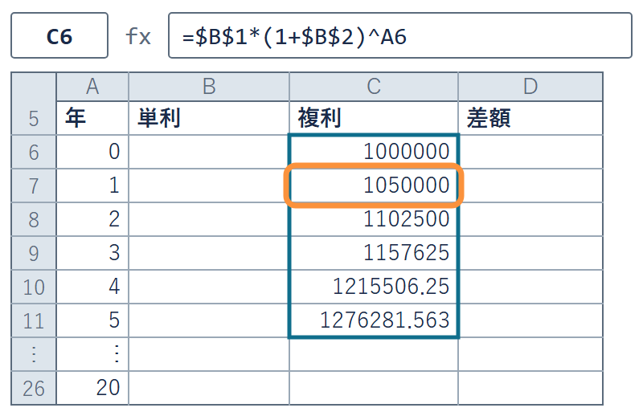

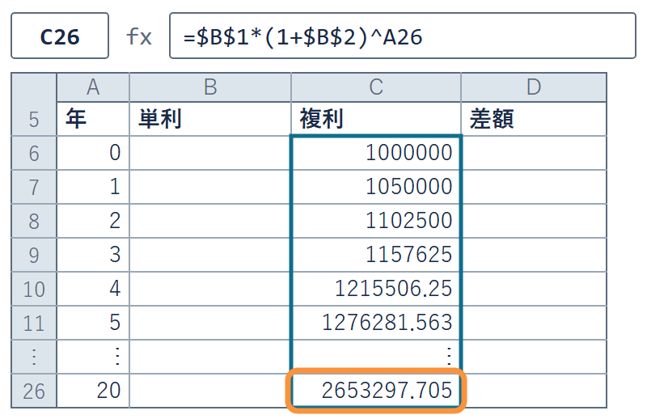

C26 は演習 4-2 の K3（2,653,298）と同じ。式は 1 本で 21 行

✋ 動画を止めて手順 1・2 を進め、C26 が 2653297.705 なら再生に戻る